# Practico Módulo 3: Análisis de Componentes Principales y Clusters

Programación funcional y estadística avanzada

Author

Gerardo Esteban, Gómez-Santiago

Published

February 11, 2025

La base ‘basePractico3.RData’ contiene información de 6 tipos de problematicas de seguridad en los municipios del departamento de Antioquia. La idea es replicar el análisis de la clase con estos datos cuya dimensión territorial es menor y por lo tanto puede ser mas pertinente.

## Ejercicio 1

- Calcula las componentes principales de las 6 variables (Extorsión, Hurto, Homicidio, V.Iterpersonal, Secuestro y V.Intrafamiliar).
- Cuales son las variables que mas aportan en la componente principal 1 y en la componente principal 2?
- La variable secuestro tiene muchos ceros, que pasa si la sacamos del análisis, afecta significativamente las conclusiones previas?
- Consideras que existen valores extremos en los datos?

```r
rm(list = ls())

library(tidyverse)
library(factoextra)

load(file = "basePractico3.RData")

base %>% glimpse()
```

```
Rows: 125
Columns: 8
$ Código.Entidad  <chr> "05656", "05652", "05649", "05647", "05642", "05631", …
$ Entidad         <chr> "San Jerónimo", "San Francisco", "San Carlos", "San An…
$ Extorsión       <dbl> 6.37, 0.00, 43.91, 41.44, 32.93, 16.38, 10.92, 27.23, …
$ Hurto           <dbl> 477.40, 173.13, 301.13, 303.87, 263.48, 1160.45, 54.62…
$ Homicidio       <dbl> 89.12, 0.00, 12.55, 55.25, 65.87, 8.19, 43.69, 7.88, 8…
$ V.Interpersonal <dbl> 44.56, 34.63, 194.48, 469.61, 203.10, 182.49, 10.92, 1…
$ Secuestro       <dbl> 0.00, 0.00, 0.00, 0.00, 0.00, 0.00, 0.00, 0.00, 0.00, …
$ V.Intrafamiliar <dbl> 31.83, 17.31, 175.66, 234.81, 137.23, 63.17, 0.00, 87.…
```

```r
# PCA

matrizPCA <- base %>%
  select(3:8) %>%
  scale()

pca <- princomp(x = matrizPCA)

summary(pca, loadings = T)
```

```
Importance of components:
                          Comp.1    Comp.2    Comp.3    Comp.4     Comp.5
Standard deviation     1.4080043 1.1114257 0.9939684 0.9404427 0.75000591
Proportion of Variance 0.3330773 0.2075382 0.1659901 0.1485942 0.09450754
Cumulative Proportion  0.3330773 0.5406155 0.7066056 0.8551998 0.94970731
                           Comp.6
Standard deviation     0.54712164
Proportion of Variance 0.05029269
Cumulative Proportion  1.00000000

Loadings:
                Comp.1 Comp.2 Comp.3 Comp.4 Comp.5 Comp.6
Extorsión        0.103  0.564  0.174  0.768  0.212
Hurto            0.482 -0.283 -0.136  0.361 -0.725  0.115
Homicidio               0.748        -0.387 -0.533
V.Interpersonal  0.629               -0.123  0.207 -0.734
Secuestro               0.127 -0.973  0.111  0.120
V.Intrafamiliar  0.591  0.139        -0.320  0.297  0.660
```

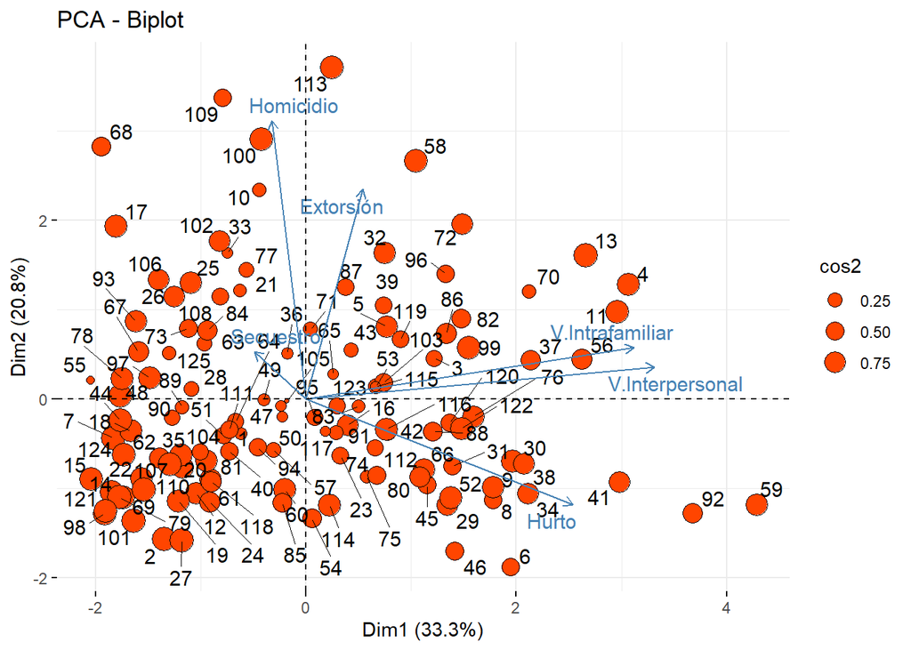

```r
fviz_pca_biplot(X = pca,
                pointshape = 21,
                pointsize = "cos2",
                repel = T,
                fill.ind = "orangered")
```

```r
matrizPCA2 <- base %>%
  select(Extorsión, Hurto, V.Interpersonal, Homicidio, V.Intrafamiliar) %>%
  scale()


# PCA sin secuestro

pca2 <- princomp(x = matrizPCA2)

summary(pca2, loadings = T)
```

```
Importance of components:
                          Comp.1    Comp.2    Comp.3    Comp.4     Comp.5
Standard deviation     1.4049150 1.1095678 0.9411556 0.7541069 0.54829014
Proportion of Variance 0.3979407 0.2482139 0.1785834 0.1146527 0.06060929
Cumulative Proportion  0.3979407 0.6461546 0.8247380 0.9393907 1.00000000

Loadings:
                Comp.1 Comp.2 Comp.3 Comp.4 Comp.5
Extorsión        0.104  0.572  0.781  0.211
Hurto            0.485 -0.299  0.342 -0.739  0.111
V.Interpersonal  0.630        -0.121  0.215 -0.732
Homicidio               0.749 -0.391 -0.530
V.Intrafamiliar  0.595  0.129 -0.325  0.288  0.664
```

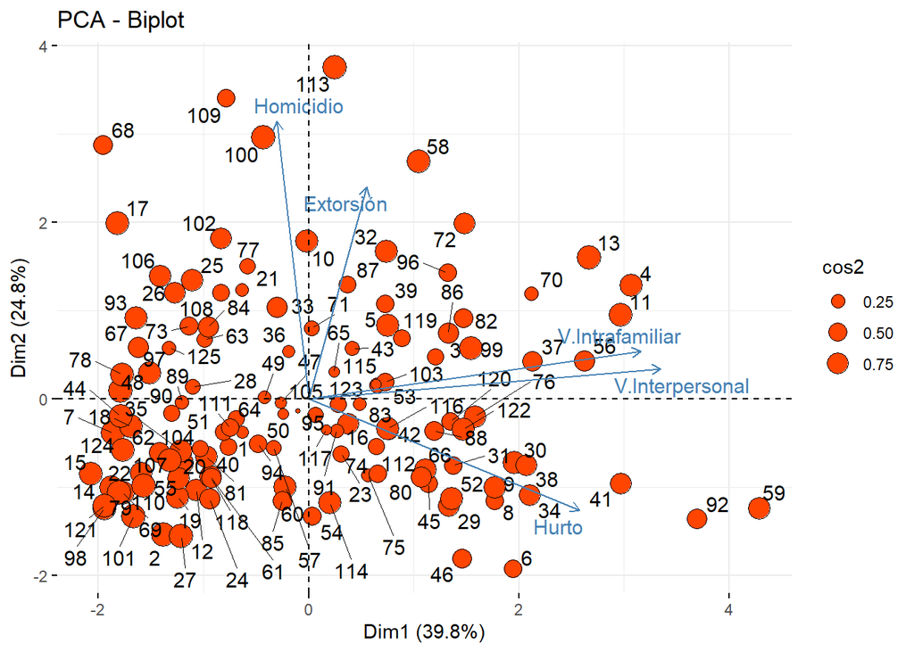

```r
fviz_pca_biplot(X = pca2,
                pointshape = 21,
                pointsize = "cos2",
                repel = T,
                fill.ind = "orangered")
```

## Ejercicio 2

El método de kmeans para obtener subgrupos es bastante simple, utiliza el criterio de la silueta para determinar cuantos clusters usar y calcula los clusters

Realiza el grafico de biplot coloreando los puntos por cluster. Si previamente consideraste que habian valores extremos, sacalos y vuelve a calcular los grupos con kmeans, ten cuidado, de pronto con este cambio, el metodo de la silueta pide otro numero de clusters.

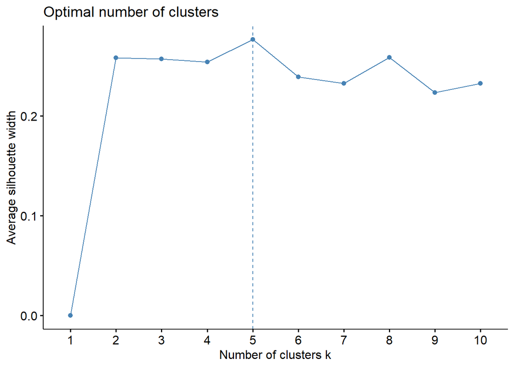

```r
fviz_nbclust(x = matrizPCA, FUNcluster = kmeans, method = "silhouette")
```

```r
kmedias <- kmeans(x = matrizPCA, centers = 4, nstart = 8)

kmedias$tot.withinss
```

```
[1] 393.4463
```

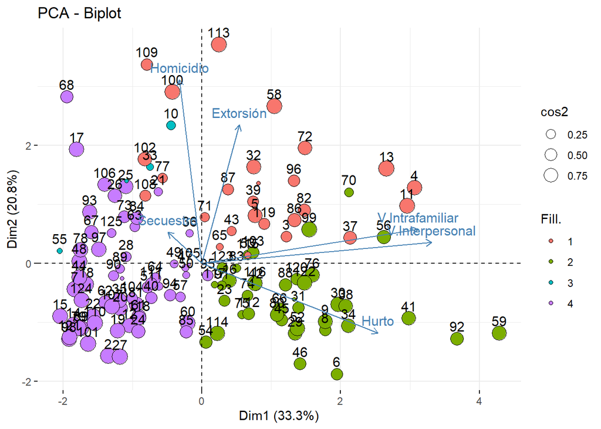

```r
clusters <- kmedias$cluster

fviz_pca_biplot(X = pca,
                pointshape = 21,
                pointsize = "cos2",
                fill.ind = as.factor(clusters))
```

```r
matrizPCA3 <- scale(matrizPCA[-c(59, 92, 113, 109), ])

pca3 <- princomp(x = matrizPCA3)

summary(pca3, loadings = T)
```

```
Importance of components:
                          Comp.1    Comp.2    Comp.3    Comp.4     Comp.5
Standard deviation     1.3989752 1.1165344 0.9930569 0.9458347 0.76233363
Proportion of Variance 0.3289068 0.2095063 0.1657300 0.1503430 0.09766592
Cumulative Proportion  0.3289068 0.5384131 0.7041431 0.8544862 0.95215209
                           Comp.6
Standard deviation     0.53358676
Proportion of Variance 0.04784791
Cumulative Proportion  1.00000000

Loadings:
                Comp.1 Comp.2 Comp.3 Comp.4 Comp.5 Comp.6
Extorsión        0.155  0.527  0.258  0.740  0.255  0.140
Hurto            0.453 -0.319 -0.166  0.410 -0.697  0.109
Homicidio               0.752        -0.331 -0.566
V.Interpersonal  0.639               -0.113  0.205 -0.730
Secuestro               0.204 -0.947  0.158  0.158
V.Intrafamiliar  0.594               -0.371  0.249  0.656
```

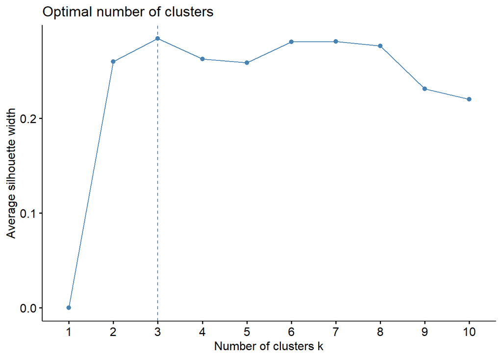

```r
fviz_nbclust(x = matrizPCA3, FUNcluster = kmeans, method = "silhouette")
```

```r
kmedias3 <- kmeans(x = matrizPCA3, centers = 3, nstart = 23)

# 23
kmedias3$tot.withinss
```

```
[1] 432.8767
```

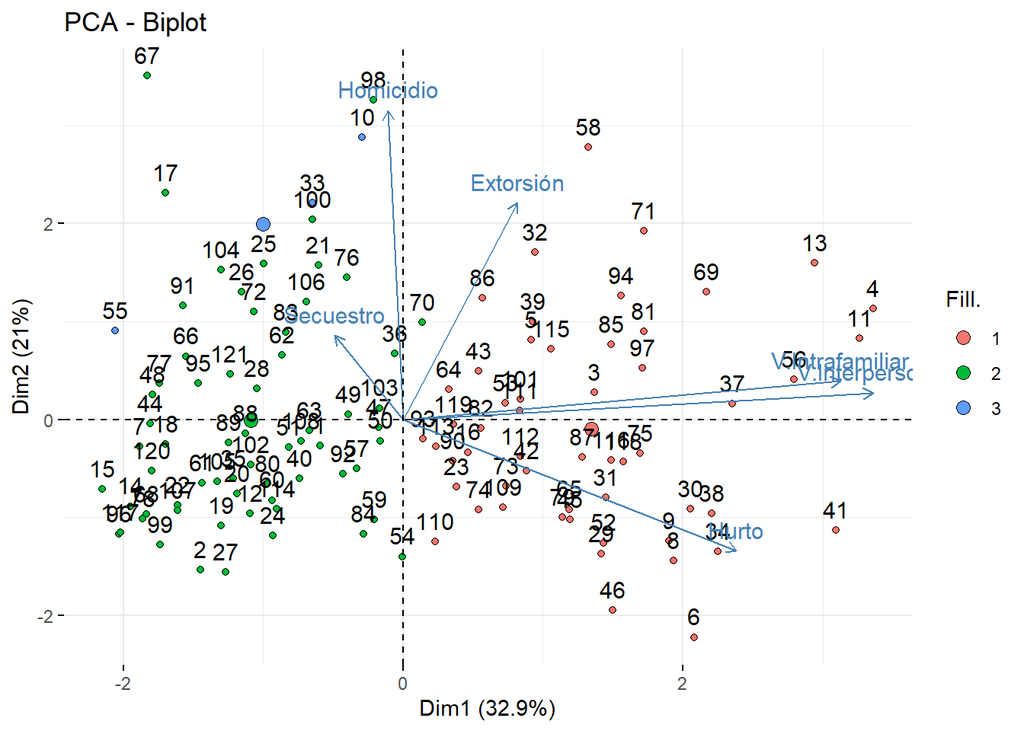

```r
clusters3 <- kmedias3$cluster

fviz_pca_biplot(X = pca3,
                pointshape = 21,
                fill.ind = as.factor(clusters3))
```

## Ejercicio 3

¿Te animas a calcular un indice a partir de los valores de las componentes principales e identificar los 10 municipios con mas problemas y los 10 con menos?

¿Estaran ubicados cerca desde el punto de vista geografico?

```r
baseInd <- tibble(municipio = base$Entidad)

eig <- eigen(x = cor(matrizPCA))

eig$values
```

```
[1] 1.9984639 1.2452289 0.9959408 0.8915651 0.5670452 0.3017561
```

```r
for(i in 1:6){

  baseInd[,i+1] <- pca$scores[,i]*eig$values[i]

}

baseInd$ind <- rowSums(baseInd[,c(2:7)])

baseInd$ind <- GGally::rescale01(baseInd$ind)*1

baseInd$ind
```

```
  [1] 0.4086371 0.3096292 0.8198069 1.0000000 0.7250551 0.6212734 0.3469966
  [8] 0.6964595 0.6911011 0.4729937 0.9281387 0.3447765 0.9155565 0.2755397
 [15] 0.2672700 0.5917352 0.4936082 0.4055449 0.3531094 0.4350800 0.4552853
 [22] 0.4003753 0.5603332 0.4045426 0.5079635 0.5729309 0.3189586 0.4031271
 [29] 0.5905884 0.7128857 0.5929908 0.7895120 0.3493386 0.7115299 0.4356587
 [36] 0.5417596 0.9003050 0.7109129 0.7931145 0.5008183 0.7416420 0.6605431
 [43] 0.7099868 0.3527629 0.5644202 0.5554046 0.5708024 0.3764946 0.5274617
 [50] 0.5613845 0.4216783 0.5902041 0.6179260 0.4611545 0.0000000 0.7931953
 [57] 0.4542528 0.8891574 0.8162887 0.4499772 0.3750094 0.4420365 0.6006946
 [64] 0.4407411 0.6246373 0.6035167 0.5111971 0.3901733 0.2825243 0.7573840
 [71] 0.5498700 0.9273489 0.4287406 0.6222026 0.5361604 0.7256553 0.7366859
 [78] 0.4432994 0.3152462 0.5864933 0.4423828 0.7712397 0.6108418 0.5667119
 [85] 0.4328246 0.7240651 0.7768610 0.6118800 0.5635993 0.5274571 0.5873815
 [92] 0.8404860 0.4284756 0.5125838 0.5563537 0.9155790 0.4677729 0.2709513
 [99] 0.7502071 0.7027404 0.2854241 0.5956272 0.6298365 0.3855045 0.4756369
[106] 0.5608440 0.3802042 0.6552454 0.4976432 0.3314214 0.4177955 0.5443211
[113] 0.8337372 0.4891003 0.6774402 0.5967258 0.4907257 0.4107397 0.6875067
[120] 0.7272565 0.2874328 0.6654811 0.5722031 0.3737856 0.6344072
```

```r
# Analisis espacial

library(sf)

mapa <- st_read(dsn = "pca/MGN_MPIO_POLITICO.shp")
mapa %>% glimpse()
```

```
Rows: 1,122
Columns: 11
$ DPTO_CCDGO <chr> "18", "18", "18", "18", "18", "18", "18", "18", "18", "18",…
$ MPIO_CCDGO <chr> "001", "029", "094", "247", "256", "410", "460", "479", "61…
$ MPIO_CNMBR <chr> "FLORENCIA", "ALBANIA", "BELÉN DE LOS ANDAQUÍES", "EL DONCE…
$ MPIO_CRSLC <chr> "Decreto 642 de Junio 17 de 1912", "Ordenanza 3 de Noviembr…
$ MPIO_NAREA <dbl> 2547.6375, 414.1221, 1191.6186, 1106.0762, 1234.7341, 1701.…
$ MPIO_CCNCT <chr> "18001", "18029", "18094", "18247", "18256", "18410", "1846…
$ MPIO_NANO  <int> 2018, 2018, 2018, 2018, 2018, 2018, 2018, 2018, 2018, 2018,…
$ DPTO_CNMBR <chr> "CAQUETÁ", "CAQUETÁ", "CAQUETÁ", "CAQUETÁ", "CAQUETÁ", "CAQ…
$ Shape_Leng <dbl> 2.9425078, 1.1128289, 2.2346567, 3.1543703, 3.5293159, 3.40…
$ Shape_Area <dbl> 0.20692777, 0.03361758, 0.09674460, 0.08986744, 0.10030928,…
$ geometry   <MULTIPOLYGON [°]> MULTIPOLYGON (((-75.42074 2..., MULTIPOLYGON (…
```

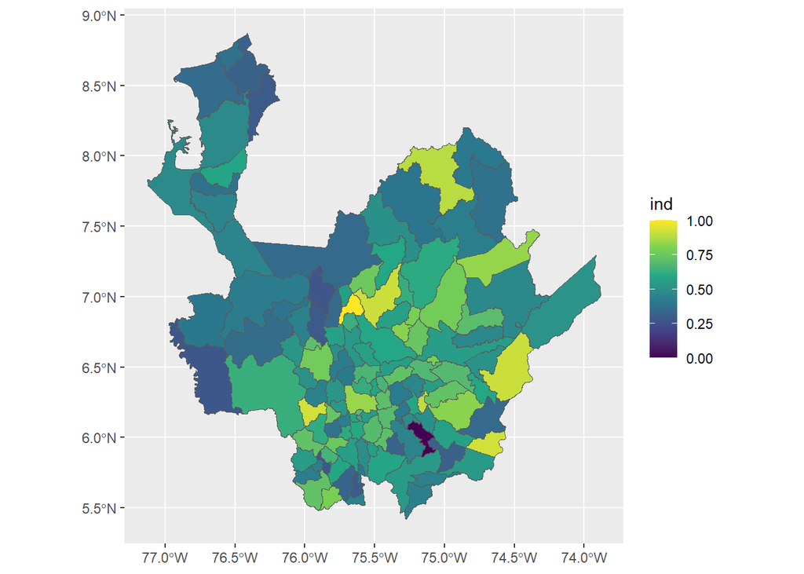

```r
mapa <- mapa %>%
  filter(DPTO_CCDGO == "05")

mapa <- mapa %>%
  mutate(codigo = str_c(DPTO_CCDGO, MPIO_CCDGO)) %>%
  left_join(y = baseInd %>%
              mutate(codigo = base$Código.Entidad) %>%
              select(codigo, ind, municipio),
            by = "codigo")


mapa %>%
  ggplot() +
  geom_sf(mapping = aes(fill = ind)) +
  scale_fill_continuous(type = "viridis")
```

Los 10 municipios con menos problemas según el índice construido a partir de PCA

```r
baseInd %>%
  arrange(ind) %>%
  mutate(id = 1:nrow(baseInd)) %>%
  filter(id < 11) %>%
  select(municipio, ind, id)
```

```
# A tibble: 10 × 3
   municipio            ind    id
   <chr>              <dbl> <int>
 1 Cocorná            0         1
 2 Peque              0.267     2
 3 Vigía del Fuerte   0.271     3
 4 Pueblorrico        0.276     4
 5 Buriticá           0.283     5
 6 Valparaíso         0.285     6
 7 San Pedro de Urabá 0.287     7
 8 San Francisco      0.310     8
 9 Arboletes          0.315     9
10 La Unión           0.319    10
```

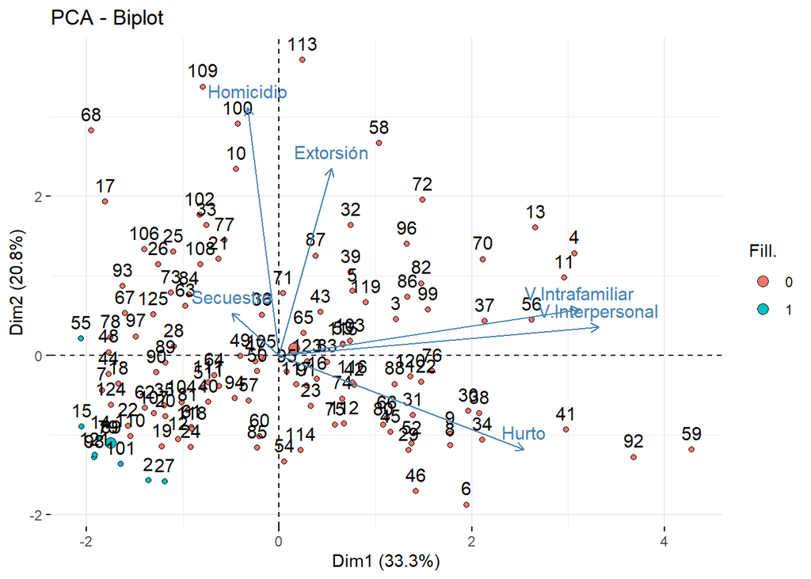

```r
base <- base %>%
  left_join(y =
              baseInd %>%
              arrange(ind) %>%
              mutate(id = 1:nrow(baseInd)) %>%
              filter(id < 11) %>%
              select(municipio, id),
            by = c("Entidad" = "municipio")) %>%
  mutate(id = ifelse(is.na(id), 0, 1))

fviz_pca_biplot(X = pca,
                pointshape = 21,
                fill.ind = as.factor(base$id))
```

Los 10 municipios con más problemas según el índice construido a partir de PCA

```r
baseInd %>%
  arrange(desc(ind)) %>%
  mutate(id = 1:nrow(baseInd)) %>%
  filter(id < 11) %>%
  select(municipio, ind, id)
```

```
# A tibble: 10 × 3
   municipio                ind    id
   <chr>                  <dbl> <int>
 1 San Andrés de Cuerquía 1         1
 2 Puerto Triunfo         0.928     2
 3 Betulia                0.927     3
 4 Yarumal                0.916     4
 5 Puerto Berrío          0.916     5
 6 Guatapé                0.900     6
 7 Caucasia               0.889     7
 8 Medellín               0.840     8
 9 Segovia                0.834     9
10 San Carlos             0.820    10
```

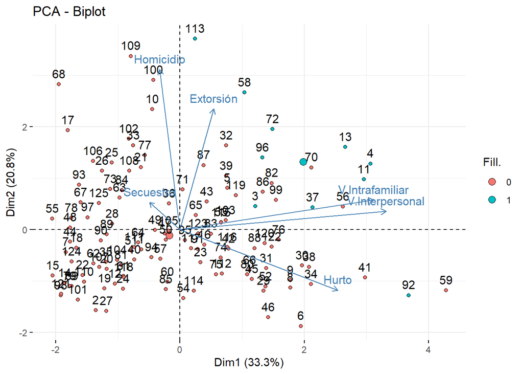

```r
base <- base %>%
  left_join(y =
              baseInd %>%
              arrange(-ind) %>%
              mutate(id = 1:nrow(baseInd)) %>%
              filter(id < 11) %>%
              select(municipio, id),
            by = c("Entidad" = "municipio")) %>%
  mutate(id.y = ifelse(is.na(id.y), 0, 1))

fviz_pca_biplot(X = pca,
                pointshape = 21,
                fill.ind = as.factor(base$id.y))
```